# Synthese des analyses du régime alimentaire du chamois dans les Vosges du Sud

Fédérations départementale des chasseurs de Haute-Saône, des Vosges et du Territoire de Belfort

3 juillet 2026

## Etat des lieux des plantes présentes dans la bdd Régime et BFC

Toutes les espèces de plantes identifiées dans le régime sont bien dans la bdd BFC. Dans le régime (lot 1, trnl), 63 plantes sont identifiées au niveau de l’espèce, 41 au genre, 10 à la famille, 3 à l’ordre et 1 à la classe. Si l’on s’intéresse à toutes les plantes de la colonne “species_list” (toutes les plantes appartenant à un genre, à une famille ou un ordre) alors il y a 19 espèces non présentes dans la bdd BFC.

## Etat des lieux des espèces animales échantillonnées

Sur 180 fecès échantillonnées, 115 sont du chamois, 11 du cerf, 4 du chevreuil et 50 n’ont été attribuées à aucune espèce. Parmi les 115 du chamois, 6 ont eu un souci dans le séquençage (0 partout). Pour les analyses suivantes, nous avons considéré que les 50 fecès non attribuées à une espèce étaient du chamois.

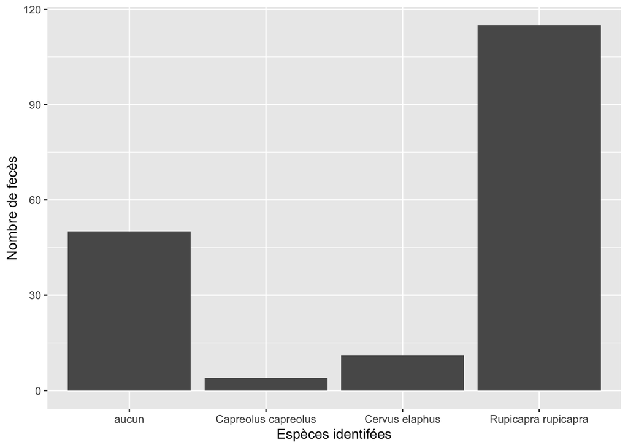

### Nombre de fecès de chamois échantillonnées par jour

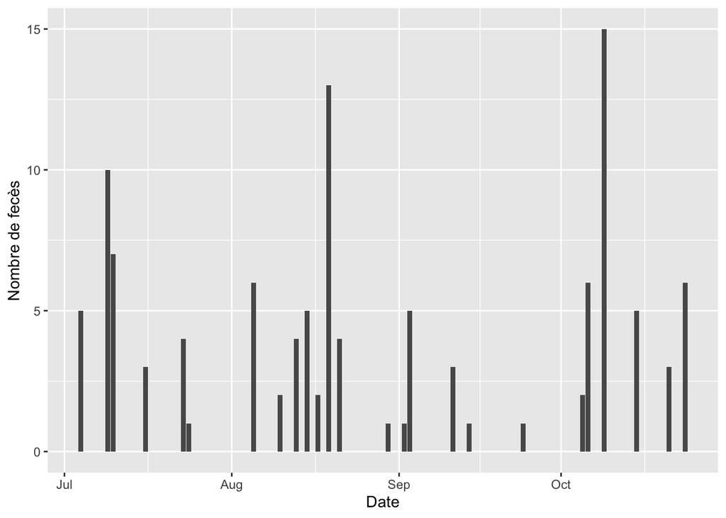

### Nombre de fecès de chamois échantillonnées par département

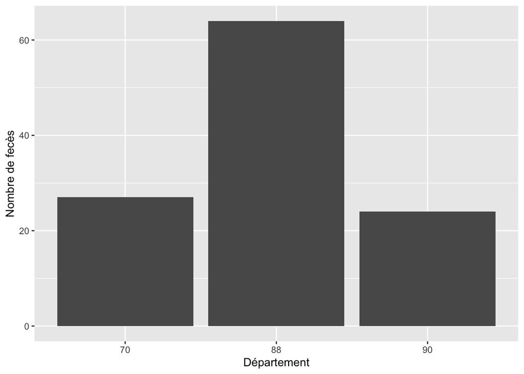

### Carte de répartition des échantillons de fecès de chamois

Les localisations sont à vérifier : échantillons sans coordonnées + mauvaises localisations pour certains

[interactive chart not shown]

## Régime alimentaire

### Composition : pourcentage moyen de chaque plante dans les fecès

Dans le graphique ci-dessous sont présentées uniquement les plantes avec une pourcentage moyen dans les fecès d’au moins 1%. Tous départements et mois confondus, les trois plantes les plus présentes dans le régime des chamois sont les rosacées, les érables et la myrtille. Les espèces listées parmi les rosacées peuvent être celles-ci : Rosa nitida, Rosa spinosissima, Fragaria vesca, Rubus caesius, Potentilla sterilis, Rubus ulmifolius, Crataegus crus-galli, Crataegus monogyna, Crataegus laevigata, Sorbus aucuparia, Malus sylvestris, Cydonia oblonga, Cotoneaster coriaceus, Cotoneaster salicifolius, Amelanchier lamarckii, Argentina anserina. Parmi les érables, cela peut concerner les espèces suivantes : Acer negundo, Acer pseudoplatanus, Acer cappadocicum, Acer campestre, Acer opalus, Acer monspessulanum.

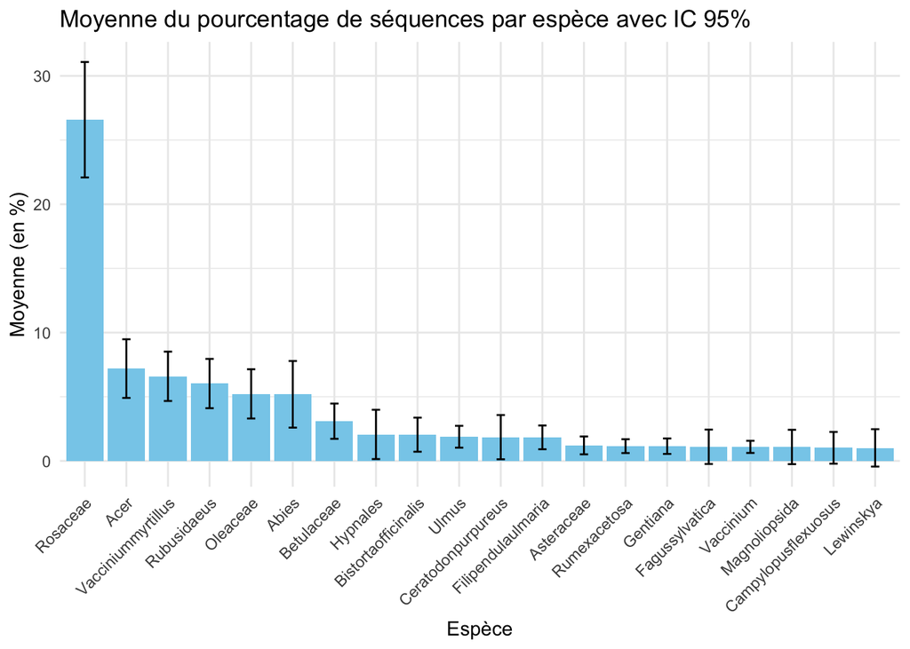

### Fréquence d’occurrence (= pourcentage de fois où une plante est présente dans une fecès)

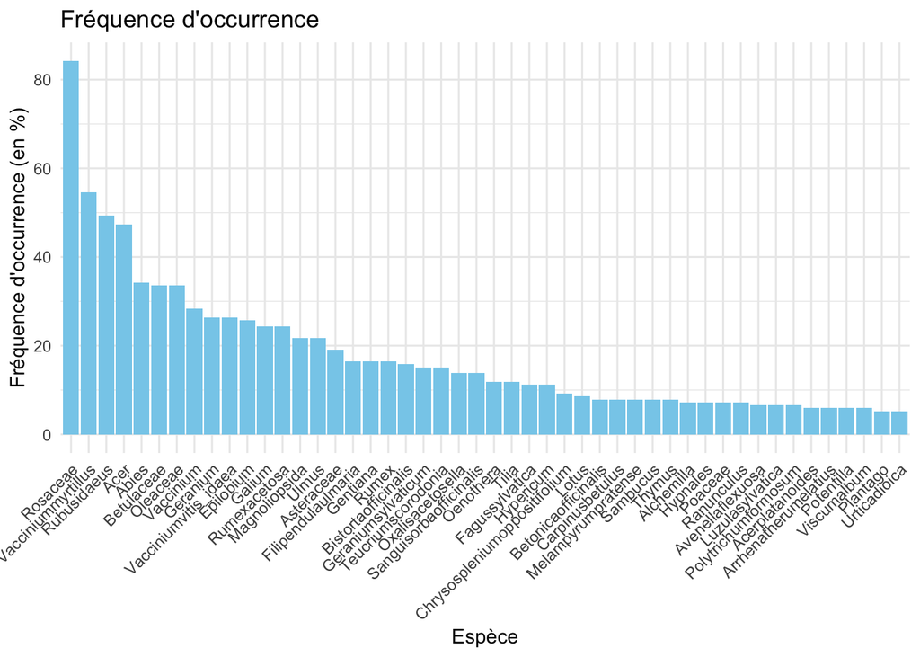

## Variabilité inter-départements

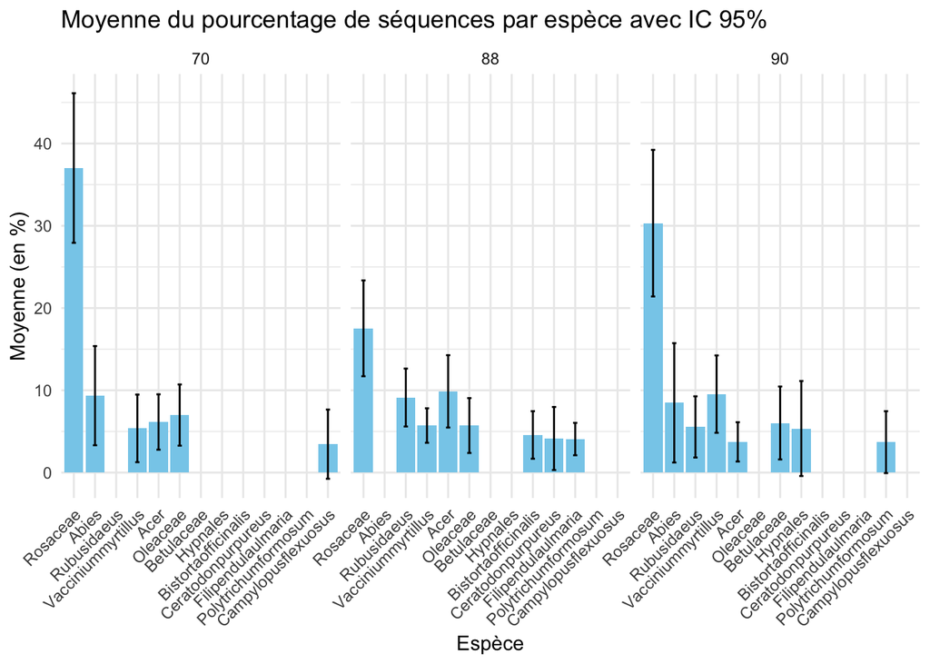

Ci-dessous est représenté l’indice de Pianka qui mesure le chevauchement entre les régimes moyens de chaque département. Plus la valeur est proche de 1 plus les régimes sont similaires entre départements.

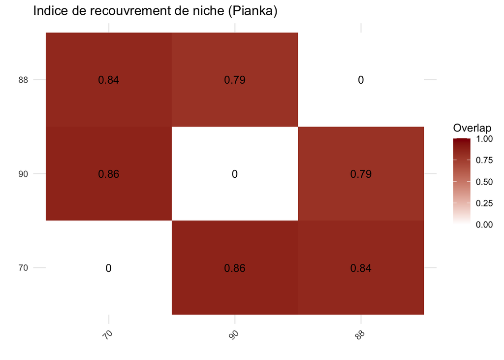

## Variabilité inter-individuelle

Dans le 88, le groupe de chamois qui consomme bcp de Acer vient principalement des circuits “Ballon servance” et “Rouge gazon”.

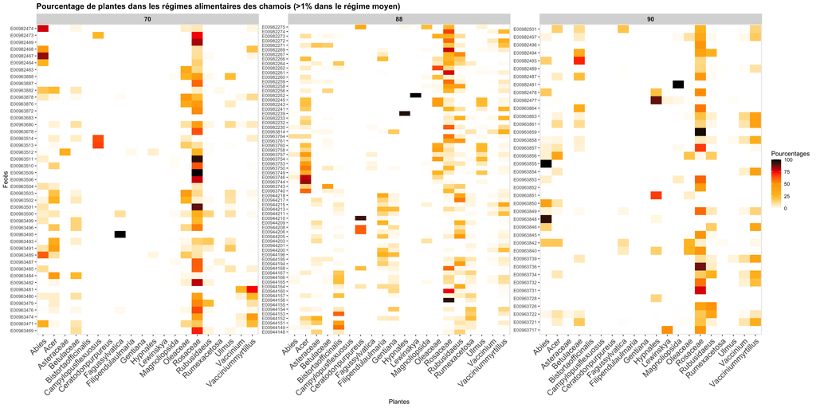

Ci-dessous est représenté une analyse en composante principale qui mesure la distance euclidienne entre chaque individus. La couleur correspond au département.

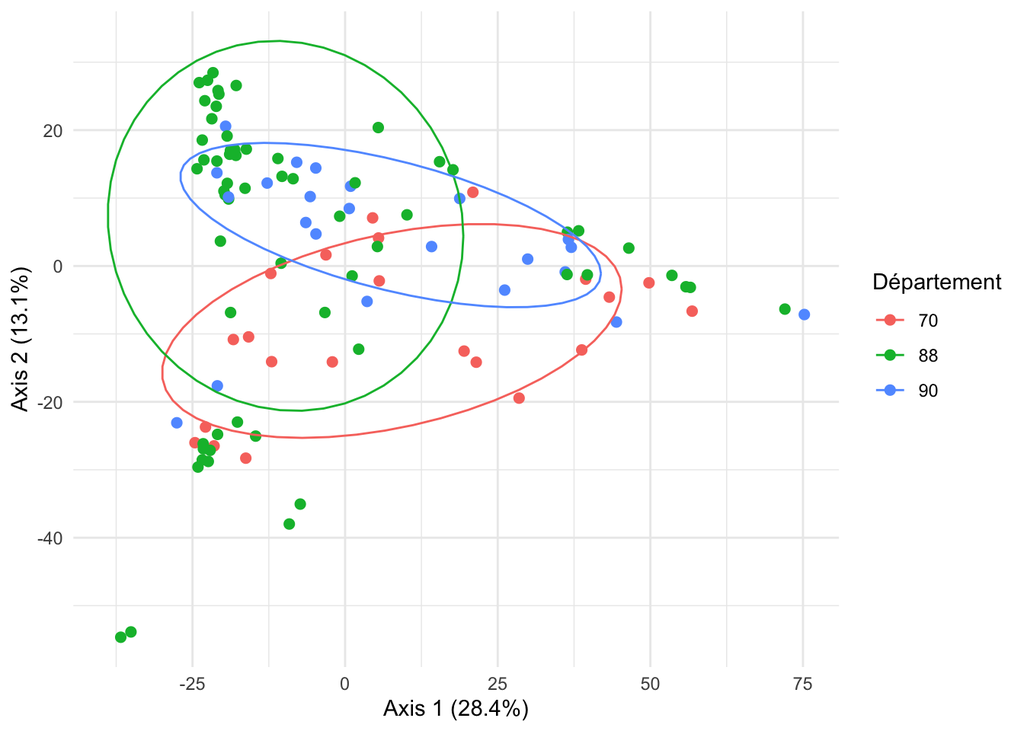

Ensuite, nous avons présenté ces distances sous forme de dendrogramme afin de voir si certaines caractéristiques (départements, mois, circuit de comptage) pouvaient visuellement expliquer les clusters.

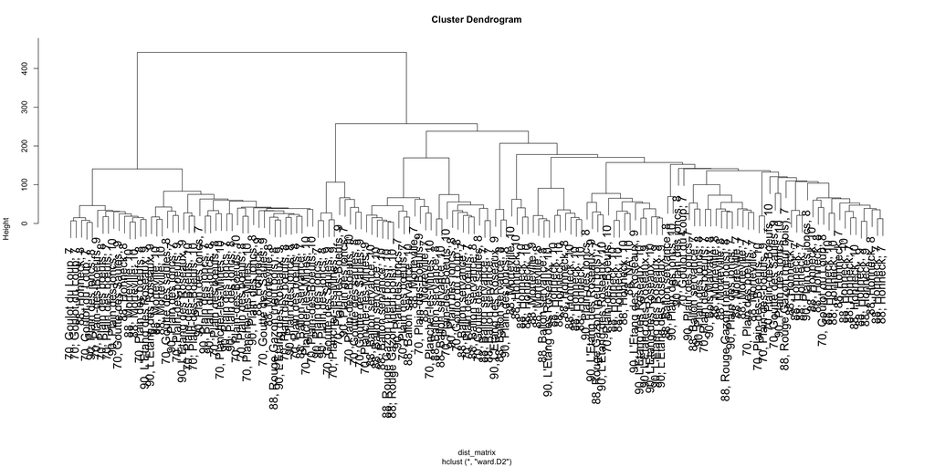

Pour finir, nous avons recalculé l’indice de recouvrement de niche entre chaque individu.

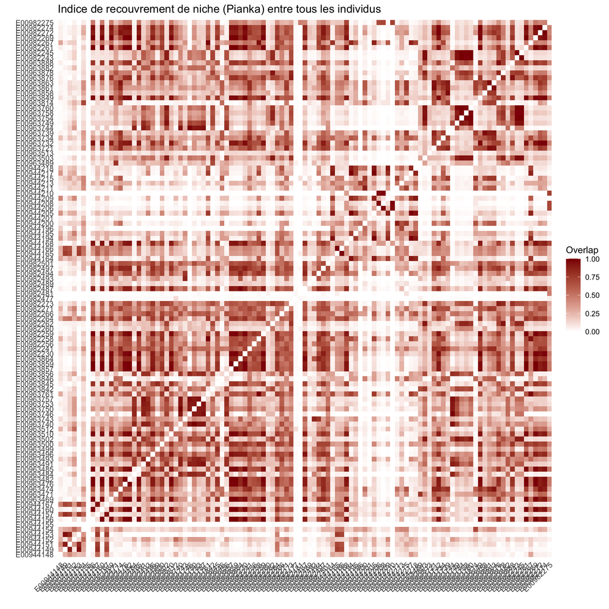

## Espèces de plantes portant à débat

Les plantes d’intérêt qui suscitent des débats quant à la présence du chamois concernent : Pensée de Vosges, Campanule de Baumgart, Lys martagon, Anémone à fleurs de Narcisse, Arnica des montagnes, Gentiane ? (autres à ajouter). Excepté la campanule de Baumgart, toutes ces essences sont bien présentes dans la liste des espèces de Bourgogne Franche-Comté. Aucune de ces plantes n’est présente au niveau spécifique dans le régime. Nous pouvons toutefois trouver des pensées (genre : Viola) dans le régime de 5 chamois.

## Pour la suite

POUR LA SUITE avec toute la base de données :

- Besoin des coordonnées correctes des collectes de crottes pour faire le lien entre distance de régime et distance géographique
- Attribuer à chaque plante une catégorie : arbres feuillus, conifères, buissons, graminées, forbs, champignons, mousses, autres et explorer les changements entre saisons
- Calcul d’indices de diversité/équitabilité
- Tester l’effet saison et département
- Clusters géographiques ?
- Comment évolue la variabilité inter-individuelle au cours de l’année ?